# Varun N Assignment 1

```python
import pandas as pd
import os
```

```python
os.chdir("D:\QTM File")
EC = pd.ExcelFile('Ecommerce_data.xlsx')
EC
```

```
<pandas.io.excel._base.ExcelFile at 0x197314b53c0>
```

```python
print(EC.sheet_names)
```

```
['Orders', 'Returns', 'People']
```

```python
orders_df = pd.read_excel(EC, 'Orders')
returns_df = pd.read_excel(EC, 'Returns')
people_df = pd.read_excel(EC, 'People')
```

```python
orders_df.head(), returns_df.head(), people_df.head()
```

```
(   Row ID                  Order ID Order Date  Ship Date     Ship Mode  \
 0   40098  CA-2014-AB10015140-41954 2014-11-11 2014-11-13   First Class
 1   26341    IN-2014-JR162107-41675 2014-02-05 2014-02-07  Second Class
 2   25330    IN-2014-CR127307-41929 2014-10-17 2014-10-18   First Class
 3   13524   ES-2014-KM1637548-41667 2014-01-28 2014-01-30   First Class
 4   47221   SG-2014-RH9495111-41948 2014-11-05 2014-11-06      Same Day

     Customer ID     Customer Name      Segment  Postal Code           City  \
 0  AB-100151402     Aaron Bergman     Consumer      73120.0  Oklahoma City
 1     JR-162107     Justin Ritter    Corporate          NaN     Wollongong
 2     CR-127307      Craig Reiter     Consumer          NaN       Brisbane
 3    KM-1637548  Katherine Murray  Home Office          NaN         Berlin
 4    RH-9495111       Rick Hansen     Consumer          NaN          Dakar

    ...   Product ID                               Product Name     Sales  \
```

[output cut: 33 more lines]

```python
merged_df = pd.merge(orders_df, returns_df, on='Order ID')
merged_df
```

|  | Row ID | Order ID | Order Date | Ship Date | Ship Mode | Customer ID | Customer Name | Segment | Postal Code | City | ... | Sales | Quantity | Discount | Profit | Shipping Cost | Order Priority | Unnamed: 22 | Unnamed: 23 | Returned | Region_y |
| --- | --- | --- | --- | --- | --- | --- | --- | --- | --- | --- | --- | --- | --- | --- | --- | --- | --- | --- | --- | --- | --- |
| 0 | 30191 | IN-2012-PB19210127-41259 | 2012-12-16 | 2012-12-19 | First Class | PB-19210127 | Phillip Breyer | Corporate | NaN | Taipei | ... | 1715.160 | 2 | 0.0 | 720.3600 | 725.570 | Critical | NaN | NaN | Yes | Eastern Asia |
| 1 | 30190 | IN-2012-PB19210127-41259 | 2012-12-16 | 2012-12-19 | First Class | PB-19210127 | Phillip Breyer | Corporate | NaN | Taipei | ... | 2197.500 | 5 | 0.0 | 153.7500 | 627.270 | Critical | NaN | NaN | Yes | Eastern Asia |
| 2 | 30187 | IN-2012-PB19210127-41259 | 2012-12-16 | 2012-12-19 | First Class | PB-19210127 | Phillip Breyer | Corporate | NaN | Taipei | ... | 1356.030 | 3 | 0.0 | 311.8500 | 458.970 | Critical | NaN | NaN | Yes | Eastern Asia |
| 3 | 30193 | IN-2012-PB19210127-41259 | 2012-12-16 | 2012-12-19 | First Class | PB-19210127 | Phillip Breyer | Corporate | NaN | Taipei | ... | 882.150 | 5 | 0.0 | 114.6000 | 203.920 | Critical | NaN | NaN | Yes | Eastern Asia |
| 4 | 30189 | IN-2012-PB19210127-41259 | 2012-12-16 | 2012-12-19 | First Class | PB-19210127 | Phillip Breyer | Corporate | NaN | Taipei | ... | 148.320 | 3 | 0.0 | 68.2200 | 25.480 | Critical | NaN | NaN | Yes | Eastern Asia |
| ... | ... | ... | ... | ... | ... | ... | ... | ... | ... | ... | ... | ... | ... | ... | ... | ... | ... | ... | ... | ... | ... |
| 2215 | 35040 | CA-2014-WB21850140-41654 | 2014-01-15 | 2014-01-21 | Standard Class | WB-218501406 | William Brown | Consumer | 10011.0 | New York City | ... | 49.536 | 3 | 0.2 | 17.3376 | 2.670 | Medium | NaN | NaN | Yes | Eastern US |
| 2216 | 35038 | CA-2014-WB21850140-41654 | 2014-01-15 | 2014-01-21 | Standard Class | WB-218501406 | William Brown | Consumer | 10011.0 | New York City | ... | 16.520 | 4 | 0.0 | 7.5992 | 1.690 | Medium | NaN | NaN | Yes | Eastern US |
| 2217 | 25 | US-2013-SJ2021582-41543 | 2013-09-26 | 2013-09-29 | First Class | SJ-2021582 | Sarah Jordon | Consumer | NaN | Hermosillo | ... | 181.116 | 9 | 0.4 | -75.5640 | 1.085 | Medium | NaN | NaN | Yes | Central America |
| 2218 | 36974 | CA-2012-ZC21910140-41271 | 2012-12-28 | 2013-01-04 | Standard Class | ZC-219101402 | Zuschuss Carroll | Consumer | 60610.0 | Chicago | ... | 38.976 | 3 | 0.6 | -50.6688 | 5.290 | Low | NaN | NaN | Yes | Central US |
| 2219 | 41315 | EG-2014-PM894038-41846 | 2014-07-26 | 2014-07-30 | Standard Class | PM-894038 | Paul MacIntyre | Consumer | NaN | Alexandria | ... | 25.830 | 1 | 0.0 | 9.0300 | 1.050 | Medium | NaN | NaN | Yes | North Africa |

2220 rows × 26 columns

```python
merged_df.shape
```

```
(2220, 26)
```

```python
merged_df.isnull().any().sum()
```

```
3
```

```python
ec = merged_df.dropna(axis=1)
```

```python
ec.shape
```

```
(2220, 23)
```

```python
list(ec)
```

```
['Row ID',
 'Order ID',
 'Order Date',
 'Ship Date',
 'Ship Mode',
 'Customer ID',
 'Customer Name',
 'Segment',
 'City',
 'State',
 'Country',
 'Region_x',
 'Market',
 'Product ID',
 'Product Name',
 'Sales',
 'Quantity',
 'Discount',
 'Profit',
 'Shipping Cost',
 'Order Priority',
 'Returned',
 'Region_y']
```

# 1.What is the total value of the order that was returned?

```python
total_returned_value = ec['Sales'].sum()
print('The Total Returned Value is',total_returned_value)
```

```
The Total Returned Value is 525932.22736
```

# 2.What is the total returned value by region?

```python
returned_value_by_region = ec.groupby(['Region_y'])[['Sales']].sum()
returned_value_by_region
```

| Region_y | Sales |
| --- | --- |
| Caribbean | 9679.32828 |
| Central Africa | 4038.48000 |
| Central America | 44334.79916 |
| Central Asia | 359.03100 |
| Central US | 23306.14500 |
| Eastern Africa | 2026.44000 |
| Eastern Asia | 47798.04300 |
| Eastern Canada | 2639.91000 |
| Eastern Europe | 9501.21000 |
| Eastern US | 23477.32600 |
| North Africa | 10193.37000 |
| Northern Europe | 17768.64000 |
| Oceania | 46943.33100 |
| South America | 29845.11212 |
| Southeastern Asia | 36967.09830 |
| Southern Africa | 7321.86000 |
| Southern Asia | 25159.36500 |
| Southern Europe | 34226.34300 |
| Southern US | 17024.59700 |
| Western Africa | 3928.15800 |
| Western Asia | 11737.63800 |
| Western Canada | 676.50000 |
| Western Europe | 72669.48450 |
| Western US | 44310.01800 |

```python
import numpy as np
import matplotlib.pyplot as plt
import seaborn as sns
```

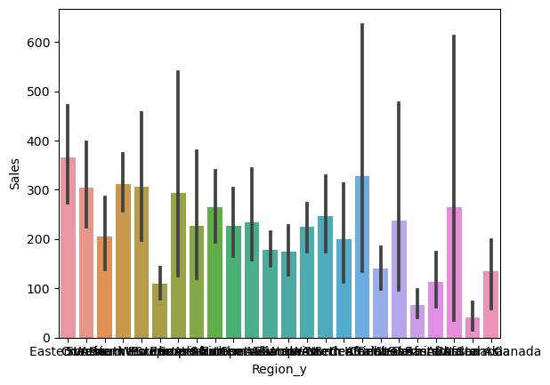

```python
 sns.barplot(x=ec.Region_y, y=ec['Sales'])
```

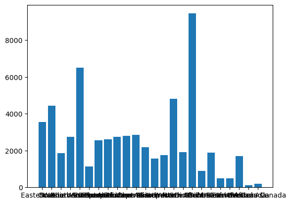

```python
plt.bar(ec.Region_y, ec.Sales);
```

# 4. What is total number of products returned whose unit price is more than 100dollars?

```python
ec['Unit Price'] = ec['Sales'] / ec['Quantity']
ec
```

|  | Row ID | Order ID | Order Date | Ship Date | Ship Mode | Customer ID | Customer Name | Segment | City | State | ... | Product Name | Sales | Quantity | Discount | Profit | Shipping Cost | Order Priority | Returned | Region_y | Unit Price |
| --- | --- | --- | --- | --- | --- | --- | --- | --- | --- | --- | --- | --- | --- | --- | --- | --- | --- | --- | --- | --- | --- |
| 0 | 30191 | IN-2012-PB19210127-41259 | 2012-12-16 | 2012-12-19 | First Class | PB-19210127 | Phillip Breyer | Corporate | Taipei | Taipei City | ... | Lesro Conference Table, with Bottom Storage | 1715.160 | 2 | 0.0 | 720.3600 | 725.570 | Critical | Yes | Eastern Asia | 857.580 |
| 1 | 30190 | IN-2012-PB19210127-41259 | 2012-12-16 | 2012-12-19 | First Class | PB-19210127 | Phillip Breyer | Corporate | Taipei | Taipei City | ... | Safco Classic Bookcase, Pine | 2197.500 | 5 | 0.0 | 153.7500 | 627.270 | Critical | Yes | Eastern Asia | 439.500 |
| 2 | 30187 | IN-2012-PB19210127-41259 | 2012-12-16 | 2012-12-19 | First Class | PB-19210127 | Phillip Breyer | Corporate | Taipei | Taipei City | ... | Lesro Round Table, with Bottom Storage | 1356.030 | 3 | 0.0 | 311.8500 | 458.970 | Critical | Yes | Eastern Asia | 452.010 |
| 3 | 30193 | IN-2012-PB19210127-41259 | 2012-12-16 | 2012-12-19 | First Class | PB-19210127 | Phillip Breyer | Corporate | Taipei | Taipei City | ... | Office Star Swivel Stool, Adjustable | 882.150 | 5 | 0.0 | 114.6000 | 203.920 | Critical | Yes | Eastern Asia | 176.430 |
| 4 | 30189 | IN-2012-PB19210127-41259 | 2012-12-16 | 2012-12-19 | First Class | PB-19210127 | Phillip Breyer | Corporate | Taipei | Taipei City | ... | Okidata Calculator, Red | 148.320 | 3 | 0.0 | 68.2200 | 25.480 | Critical | Yes | Eastern Asia | 49.440 |
| ... | ... | ... | ... | ... | ... | ... | ... | ... | ... | ... | ... | ... | ... | ... | ... | ... | ... | ... | ... | ... | ... |
| 2215 | 35040 | CA-2014-WB21850140-41654 | 2014-01-15 | 2014-01-21 | Standard Class | WB-218501406 | William Brown | Consumer | New York City | New York | ... | Square Ring Data Binders, Rigid 75 Pt. Covers,... | 49.536 | 3 | 0.2 | 17.3376 | 2.670 | Medium | Yes | Eastern US | 16.512 |
| 2216 | 35038 | CA-2014-WB21850140-41654 | 2014-01-15 | 2014-01-21 | Standard Class | WB-218501406 | William Brown | Consumer | New York City | New York | ... | #10 Gummed Flap White Envelopes, 100/Box | 16.520 | 4 | 0.0 | 7.5992 | 1.690 | Medium | Yes | Eastern US | 4.130 |
| 2217 | 25 | US-2013-SJ2021582-41543 | 2013-09-26 | 2013-09-29 | First Class | SJ-2021582 | Sarah Jordon | Consumer | Hermosillo | Sonora | ... | Deflect-O Clock, Black | 181.116 | 9 | 0.4 | -75.5640 | 1.085 | Medium | Yes | Central America | 20.124 |
| 2218 | 36974 | CA-2012-ZC21910140-41271 | 2012-12-28 | 2013-01-04 | Standard Class | ZC-219101402 | Zuschuss Carroll | Consumer | Chicago | Illinois | ... | Tenex Chairmats For Use with Hard Floors | 38.976 | 3 | 0.6 | -50.6688 | 5.290 | Low | Yes | Central US | 12.992 |
| 2219 | 41315 | EG-2014-PM894038-41846 | 2014-07-26 | 2014-07-30 | Standard Class | PM-894038 | Paul MacIntyre | Consumer | Alexandria | Al Iskandariyah | ... | Sanford Pencil Sharpener, Fluorescent | 25.830 | 1 | 0.0 | 9.0300 | 1.050 | Medium | Yes | North Africa | 25.830 |

2220 rows × 24 columns

```python
ec1 = ec[ec['Unit Price'] > 100]
total_returned_products = ec1['Quantity'].sum()
print('The Total Returned Products is', total_returned_products)
```

```
The Total Returned Products is 1607
```

# 5. How many of the orders deliverd on the same day, 7days, 15days and >30 days?

```python
ec['delivery_days'] = (ec['Ship Date'] - ec['Order Date']).dt.days
ec
```

|  | Row ID | Order ID | Order Date | Ship Date | Ship Mode | Customer ID | Customer Name | Segment | City | State | ... | Quantity | Discount | Profit | Shipping Cost | Order Priority | Returned | Region_y | Unit Price | days | delivery_days |
| --- | --- | --- | --- | --- | --- | --- | --- | --- | --- | --- | --- | --- | --- | --- | --- | --- | --- | --- | --- | --- | --- |
| 0 | 30191 | IN-2012-PB19210127-41259 | 2012-12-16 | 2012-12-19 | First Class | PB-19210127 | Phillip Breyer | Corporate | Taipei | Taipei City | ... | 2 | 0.0 | 720.3600 | 725.570 | Critical | Yes | Eastern Asia | 857.580 | 3 days | 3 |
| 1 | 30190 | IN-2012-PB19210127-41259 | 2012-12-16 | 2012-12-19 | First Class | PB-19210127 | Phillip Breyer | Corporate | Taipei | Taipei City | ... | 5 | 0.0 | 153.7500 | 627.270 | Critical | Yes | Eastern Asia | 439.500 | 3 days | 3 |
| 2 | 30187 | IN-2012-PB19210127-41259 | 2012-12-16 | 2012-12-19 | First Class | PB-19210127 | Phillip Breyer | Corporate | Taipei | Taipei City | ... | 3 | 0.0 | 311.8500 | 458.970 | Critical | Yes | Eastern Asia | 452.010 | 3 days | 3 |
| 3 | 30193 | IN-2012-PB19210127-41259 | 2012-12-16 | 2012-12-19 | First Class | PB-19210127 | Phillip Breyer | Corporate | Taipei | Taipei City | ... | 5 | 0.0 | 114.6000 | 203.920 | Critical | Yes | Eastern Asia | 176.430 | 3 days | 3 |
| 4 | 30189 | IN-2012-PB19210127-41259 | 2012-12-16 | 2012-12-19 | First Class | PB-19210127 | Phillip Breyer | Corporate | Taipei | Taipei City | ... | 3 | 0.0 | 68.2200 | 25.480 | Critical | Yes | Eastern Asia | 49.440 | 3 days | 3 |
| ... | ... | ... | ... | ... | ... | ... | ... | ... | ... | ... | ... | ... | ... | ... | ... | ... | ... | ... | ... | ... | ... |
| 2215 | 35040 | CA-2014-WB21850140-41654 | 2014-01-15 | 2014-01-21 | Standard Class | WB-218501406 | William Brown | Consumer | New York City | New York | ... | 3 | 0.2 | 17.3376 | 2.670 | Medium | Yes | Eastern US | 16.512 | 6 days | 6 |
| 2216 | 35038 | CA-2014-WB21850140-41654 | 2014-01-15 | 2014-01-21 | Standard Class | WB-218501406 | William Brown | Consumer | New York City | New York | ... | 4 | 0.0 | 7.5992 | 1.690 | Medium | Yes | Eastern US | 4.130 | 6 days | 6 |
| 2217 | 25 | US-2013-SJ2021582-41543 | 2013-09-26 | 2013-09-29 | First Class | SJ-2021582 | Sarah Jordon | Consumer | Hermosillo | Sonora | ... | 9 | 0.4 | -75.5640 | 1.085 | Medium | Yes | Central America | 20.124 | 3 days | 3 |
| 2218 | 36974 | CA-2012-ZC21910140-41271 | 2012-12-28 | 2013-01-04 | Standard Class | ZC-219101402 | Zuschuss Carroll | Consumer | Chicago | Illinois | ... | 3 | 0.6 | -50.6688 | 5.290 | Low | Yes | Central US | 12.992 | 7 days | 7 |
| 2219 | 41315 | EG-2014-PM894038-41846 | 2014-07-26 | 2014-07-30 | Standard Class | PM-894038 | Paul MacIntyre | Consumer | Alexandria | Al Iskandariyah | ... | 1 | 0.0 | 9.0300 | 1.050 | Medium | Yes | North Africa | 25.830 | 4 days | 4 |

2220 rows × 26 columns

```python
same_day = ec[ec['delivery_days'] == 0].shape[0]
within_7_days = ec[(ec['delivery_days'] > 0) & (ec['delivery_days'] <= 7)].shape[0]
within_15_days = ec[(ec['delivery_days'] > 7) & (ec['delivery_days'] <= 15)].shape[0]
more_than_30_days = ec[ec['delivery_days'] > 30].shape[0]
```

```python
print(f"Same Day: {same_day}")
print(f"Within 7 Days: {within_7_days}")
print(f"Within 15 Days: {within_15_days}")
print(f"More than 30 Days: {more_than_30_days}")
```

```
Same Day: 115
Within 7 Days: 2105
Within 15 Days: 0
More than 30 Days: 0
```

# 6. Check the relationship between price and quantity?

```python
from scipy.stats import pearsonr
```

```python
 pearsonr(ec['Unit Price'],ec['Quantity'])
```

```
PearsonRResult(statistic=-0.028330344451430955, pvalue=0.18208808203223595)
```

#### The r value = -0.028 so it is a negative correlation. It Indicates almost no linear relationship between the unit price and quantity.

#### A negative value suggests that there might be a very weak inverse relationship, meaning as the price increases, the quantity might decrease slightly, but the effect is negligible.

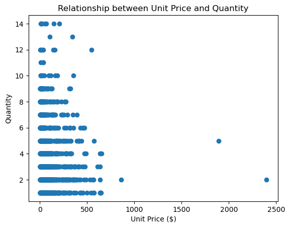

```python
plt.scatter(ec['Unit Price'], ec['Quantity'])
plt.title('Relationship between Unit Price and Quantity')
plt.xlabel('Unit Price ($)')
plt.ylabel('Quantity')
plt.show()
```

# 7. Use the calculation from question 5 and order priority. Check is there any relationship between order priority and days taken.

```python
from scipy import stats
```

```python
priority_delivery_stats = ec.groupby('Order Priority')['delivery_days'].describe()
print(priority_delivery_stats)
```

```
                 count      mean       std  min  25%  50%  75%  max
Order Priority
Critical         188.0  1.750000  1.135829  0.0  1.0  2.0  3.0  3.0
High             643.0  3.205288  1.453807  0.0  2.0  4.0  4.0  5.0
Low              125.0  6.552000  0.499290  6.0  6.0  7.0  7.0  7.0
Medium          1264.0  4.528481  1.393053  0.0  4.0  5.0  5.0  7.0
```

```python
anova_result = stats.f_oneway(
    ec[ec['Order Priority'] == 'Low']['delivery_days'],
    ec[ec['Order Priority'] == 'Medium']['delivery_days'],
    ec[ec['Order Priority'] == 'High']['delivery_days'],
    ec[ec['Order Priority'] == 'Critical']['delivery_days'])

print(f"ANOVA result: {anova_result}")
```

```
ANOVA result: F_onewayResult(statistic=456.90010105295534, pvalue=4.523164187330846e-231)
```

### The p-value from the ANOVA test is less than 0.05, it indicates a statistically significant difference in delivery times between different order priority levels.

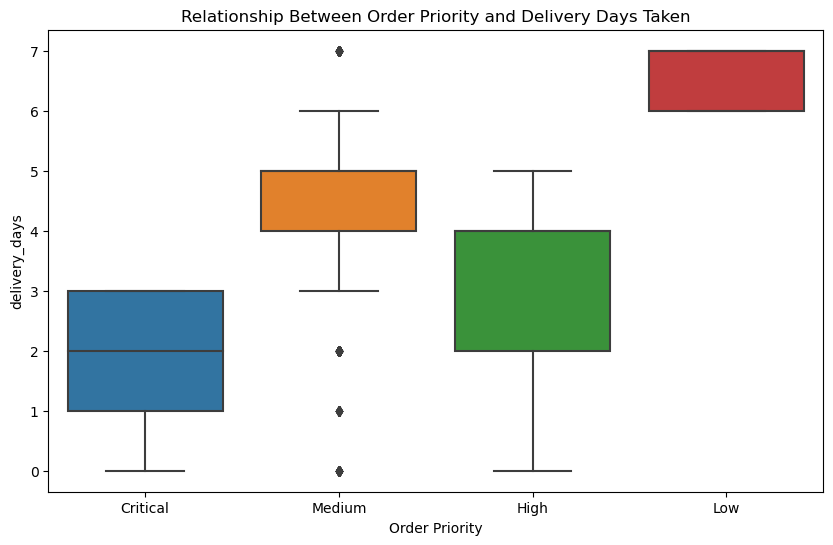

```python
plt.figure(figsize=(10, 6))
sns.boxplot(x='Order Priority', y='delivery_days', data=ec)
plt.title('Relationship Between Order Priority and Delivery Days Taken')
plt.show()
```

# 3. What is the total returned value for category and sub_category using product id?

```python
ec2 = pd.ExcelFile('Ecommerce_data2.xlsx')
ec2
```

```
<pandas.io.excel._base.ExcelFile at 0x19736df9270>
```

```python
orders_df = pd.read_excel(ec2, 'Orders')
returns_df = pd.read_excel(ec2, 'Returns')
```

```python
merged_df = pd.merge(orders_df, returns_df, on='Order ID')
```

```python
returned_value_by_category = merged_df.groupby(['Category', 'Sub-Category'])[['Sales']].sum()
returned_value_by_category
```

| Category | Sub-Category | Sales |
| --- | --- | --- |
| Furniture | Bookcases | 60710.99170 |
|  | Chairs | 57439.11790 |
|  | Furnishings | 16581.79860 |
|  | Tables | 33283.15700 |
| Office Supplies | Appliances | 32975.10160 |
|  | Art | 16221.50620 |
|  | Binders | 23571.83300 |
|  | Envelopes | 6784.22590 |
|  | Fasteners | 3098.36380 |
|  | Labels | 3349.15170 |
|  | Paper | 9928.68380 |
|  | Storage | 52938.56010 |
|  | Supplies | 8327.68320 |
| Technology | Accessories | 33991.09180 |
|  | Copiers | 65145.83696 |
|  | Machines | 32550.62610 |
|  | Phones | 69034.49800 |